# Risk Factor Analysis

## Outcome Variable

**Outcome Variable:** y_rate_wtkg

## Predictor Variables

**Intervention Variable:** parity

**Adjustment Set:**

unadjusted

## Stratifying Variables

The analysis was stratified on these variable(s):

- agecat
- studyid
- country

## Data Summary

| agecat | studyid | country | parity | n_cell | n |
| --- | --- | --- | --- | --- | --- |
| 0-3 months | COHORTS | GUATEMALA | 1 | 103 | 798 |
| 0-3 months | COHORTS | GUATEMALA | 2 | 114 | 798 |
| 0-3 months | COHORTS | GUATEMALA | 3+ | 581 | 798 |
| 0-3 months | COHORTS | INDIA | 1 | 713 | 4147 |
| 0-3 months | COHORTS | INDIA | 2 | 1045 | 4147 |
| 0-3 months | COHORTS | INDIA | 3+ | 2389 | 4147 |
| 0-3 months | GMS-Nepal | NEPAL | 1 | 137 | 509 |
| 0-3 months | GMS-Nepal | NEPAL | 2 | 130 | 509 |
| 0-3 months | GMS-Nepal | NEPAL | 3+ | 242 | 509 |
| 0-3 months | Keneba | GAMBIA | 1 | 192 | 1441 |
| 0-3 months | Keneba | GAMBIA | 2 | 149 | 1441 |
| 0-3 months | Keneba | GAMBIA | 3+ | 1100 | 1441 |
| 0-3 months | PROVIDE | BANGLADESH | 1 | 242 | 640 |
| 0-3 months | PROVIDE | BANGLADESH | 2 | 226 | 640 |
| 0-3 months | PROVIDE | BANGLADESH | 3+ | 172 | 640 |
| 0-3 months | SAS-CompFeed | INDIA | 1 | 346 | 1265 |
| 0-3 months | SAS-CompFeed | INDIA | 2 | 300 | 1265 |
| 0-3 months | SAS-CompFeed | INDIA | 3+ | 619 | 1265 |
| 0-3 months | TanzaniaChild2 | TANZANIA, UNITED REPUBLIC OF | 1 | 680 | 1996 |
| 0-3 months | TanzaniaChild2 | TANZANIA, UNITED REPUBLIC OF | 2 | 659 | 1996 |
| 0-3 months | TanzaniaChild2 | TANZANIA, UNITED REPUBLIC OF | 3+ | 657 | 1996 |
| 0-3 months | ZVITAMBO | ZIMBABWE | 1 | 3175 | 8171 |
| 0-3 months | ZVITAMBO | ZIMBABWE | 2 | 2534 | 8171 |
| 0-3 months | ZVITAMBO | ZIMBABWE | 3+ | 2462 | 8171 |
| 3-6 months | COHORTS | GUATEMALA | 1 | 107 | 809 |
| 3-6 months | COHORTS | GUATEMALA | 2 | 115 | 809 |
| 3-6 months | COHORTS | GUATEMALA | 3+ | 587 | 809 |
| 3-6 months | COHORTS | INDIA | 1 | 718 | 4194 |
| 3-6 months | COHORTS | INDIA | 2 | 1072 | 4194 |
| 3-6 months | COHORTS | INDIA | 3+ | 2404 | 4194 |

[output cut: 153 more lines]

The following strata were considered:

- agecat: 0-3 months, studyid: COHORTS, country: GUATEMALA
- agecat: 0-3 months, studyid: COHORTS, country: INDIA
- agecat: 0-3 months, studyid: GMS-Nepal, country: NEPAL
- agecat: 0-3 months, studyid: Keneba, country: GAMBIA
- agecat: 0-3 months, studyid: PROVIDE, country: BANGLADESH
- agecat: 0-3 months, studyid: SAS-CompFeed, country: INDIA
- agecat: 0-3 months, studyid: TanzaniaChild2, country: TANZANIA, UNITED REPUBLIC OF
- agecat: 0-3 months, studyid: ZVITAMBO, country: ZIMBABWE
- agecat: 12-15 months, studyid: COHORTS, country: GUATEMALA
- agecat: 12-15 months, studyid: GMS-Nepal, country: NEPAL
- agecat: 12-15 months, studyid: Keneba, country: GAMBIA
- agecat: 12-15 months, studyid: PROVIDE, country: BANGLADESH
- agecat: 12-15 months, studyid: SAS-CompFeed, country: INDIA
- agecat: 12-15 months, studyid: SAS-FoodSuppl, country: INDIA
- agecat: 12-15 months, studyid: TanzaniaChild2, country: TANZANIA, UNITED REPUBLIC OF
- agecat: 12-15 months, studyid: ZVITAMBO, country: ZIMBABWE
- agecat: 15-18 months, studyid: COHORTS, country: GUATEMALA
- agecat: 15-18 months, studyid: GMS-Nepal, country: NEPAL
- agecat: 15-18 months, studyid: Keneba, country: GAMBIA
- agecat: 15-18 months, studyid: PROVIDE, country: BANGLADESH
- agecat: 15-18 months, studyid: SAS-CompFeed, country: INDIA
- agecat: 15-18 months, studyid: SAS-FoodSuppl, country: INDIA
- agecat: 15-18 months, studyid: TanzaniaChild2, country: TANZANIA, UNITED REPUBLIC OF
- agecat: 15-18 months, studyid: ZVITAMBO, country: ZIMBABWE
- agecat: 18-21 months, studyid: COHORTS, country: GUATEMALA
- agecat: 18-21 months, studyid: GMS-Nepal, country: NEPAL
- agecat: 18-21 months, studyid: Keneba, country: GAMBIA
- agecat: 18-21 months, studyid: PROVIDE, country: BANGLADESH
- agecat: 18-21 months, studyid: TanzaniaChild2, country: TANZANIA, UNITED REPUBLIC OF
- agecat: 18-21 months, studyid: ZVITAMBO, country: ZIMBABWE
- agecat: 21-24 months, studyid: COHORTS, country: GUATEMALA
- agecat: 21-24 months, studyid: GMS-Nepal, country: NEPAL
- agecat: 21-24 months, studyid: Keneba, country: GAMBIA
- agecat: 21-24 months, studyid: PROVIDE, country: BANGLADESH
- agecat: 21-24 months, studyid: ZVITAMBO, country: ZIMBABWE
- agecat: 3-6 months, studyid: COHORTS, country: GUATEMALA
- agecat: 3-6 months, studyid: COHORTS, country: INDIA
- agecat: 3-6 months, studyid: GMS-Nepal, country: NEPAL
- agecat: 3-6 months, studyid: Keneba, country: GAMBIA
- agecat: 3-6 months, studyid: PROVIDE, country: BANGLADESH
- agecat: 3-6 months, studyid: SAS-CompFeed, country: INDIA
- agecat: 3-6 months, studyid: TanzaniaChild2, country: TANZANIA, UNITED REPUBLIC OF
- agecat: 3-6 months, studyid: ZVITAMBO, country: ZIMBABWE
- agecat: 6-9 months, studyid: COHORTS, country: GUATEMALA
- agecat: 6-9 months, studyid: COHORTS, country: INDIA
- agecat: 6-9 months, studyid: GMS-Nepal, country: NEPAL
- agecat: 6-9 months, studyid: Keneba, country: GAMBIA
- agecat: 6-9 months, studyid: PROVIDE, country: BANGLADESH
- agecat: 6-9 months, studyid: SAS-CompFeed, country: INDIA
- agecat: 6-9 months, studyid: SAS-FoodSuppl, country: INDIA
- agecat: 6-9 months, studyid: TanzaniaChild2, country: TANZANIA, UNITED REPUBLIC OF
- agecat: 6-9 months, studyid: ZVITAMBO, country: ZIMBABWE
- agecat: 9-12 months, studyid: COHORTS, country: GUATEMALA
- agecat: 9-12 months, studyid: COHORTS, country: INDIA
- agecat: 9-12 months, studyid: GMS-Nepal, country: NEPAL
- agecat: 9-12 months, studyid: Keneba, country: GAMBIA
- agecat: 9-12 months, studyid: PROVIDE, country: BANGLADESH
- agecat: 9-12 months, studyid: SAS-CompFeed, country: INDIA
- agecat: 9-12 months, studyid: SAS-FoodSuppl, country: INDIA
- agecat: 9-12 months, studyid: TanzaniaChild2, country: TANZANIA, UNITED REPUBLIC OF
- agecat: 9-12 months, studyid: ZVITAMBO, country: ZIMBABWE

### Dropped Strata

Some strata were dropped due to rare outcomes:

- agecat: 6-9 months, studyid: SAS-FoodSuppl, country: INDIA
- agecat: 9-12 months, studyid: SAS-FoodSuppl, country: INDIA
- agecat: 12-15 months, studyid: SAS-FoodSuppl, country: INDIA
- agecat: 15-18 months, studyid: SAS-FoodSuppl, country: INDIA
- agecat: 18-21 months, studyid: TanzaniaChild2, country: TANZANIA, UNITED REPUBLIC OF

## Methods Detail

We’re interested in the causal parameters $E[Y_a]$ for all values of $a \in \mathcal{A}$. These parameters represent the mean outcome if, possibly contrary to fact, we intervened to set all units to have $A=a$. Under the randomization and positivity assumptions, these are identified by the statistical parameters $\psi_a=E_W[E_{Y|A,W}(Y|A=a,W)]$. In addition, we’re interested in the mean of $Y$, $E[Y]$ under no intervention (the observed mean). We will estimate these parameters by using SuperLearner to fit the relevant likelihood factors – $E_{Y|A,W}(Y|A=a,W)$ and $p(A=a|W)$, and then updating our likelihood fit using a joint TMLE.

For unadjusted analyses ($W=\{\}$), initial likelihoods were estimated using Lrnr_glm to estimate the simple $E(Y|A)$ and Lrnr_mean to estimate $p(A)$. For adjusted analyses, a small library containing Lrnr_glmnet, Lrnr_xgboost, and Lrnr_mean was used.

# Results Detail

## Results Plots

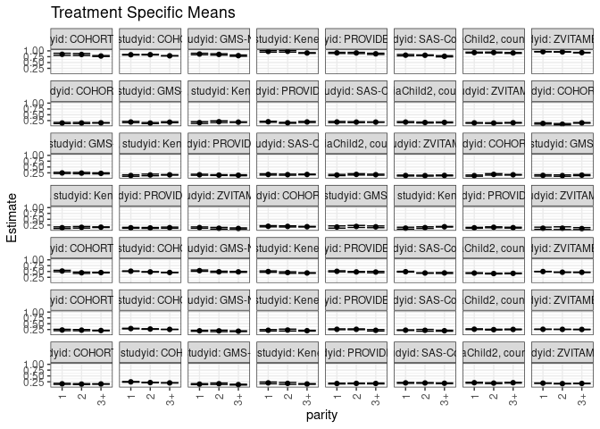

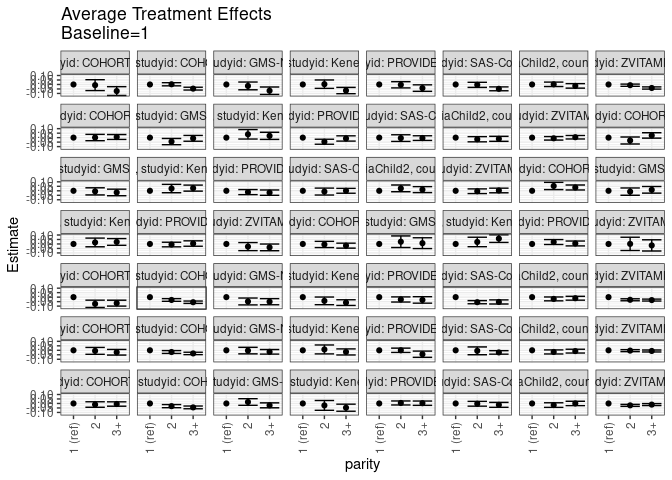

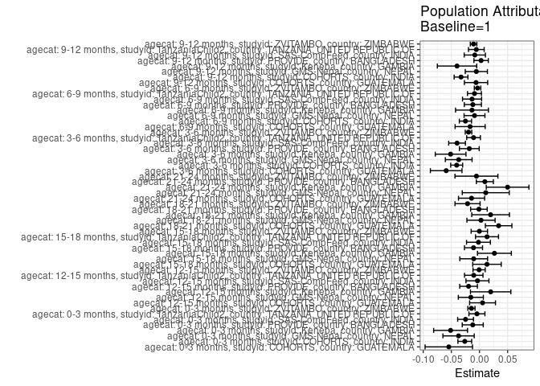

## Results Table

### Parameter: TSM

| agecat | studyid | country | intervention_level | baseline_level | estimate | ci_lower | ci_upper |
| --- | --- | --- | --- | --- | --- | --- | --- |
| 0-3 months | COHORTS | GUATEMALA | 1 | NA | 0.8525928 | 0.8077020 | 0.8974835 |
| 0-3 months | COHORTS | GUATEMALA | 2 | NA | 0.8453618 | 0.8044867 | 0.8862370 |
| 0-3 months | COHORTS | GUATEMALA | 3+ | NA | 0.7790411 | 0.7591358 | 0.7989464 |
| 0-3 months | COHORTS | INDIA | 1 | NA | 0.8340761 | 0.8208305 | 0.8473218 |
| 0-3 months | COHORTS | INDIA | 2 | NA | 0.8364009 | 0.8249784 | 0.8478234 |
| 0-3 months | COHORTS | INDIA | 3+ | NA | 0.7876403 | 0.7797524 | 0.7955282 |
| 0-3 months | GMS-Nepal | NEPAL | 1 | NA | 0.8642331 | 0.8317490 | 0.8967173 |
| 0-3 months | GMS-Nepal | NEPAL | 2 | NA | 0.8481265 | 0.8193539 | 0.8768990 |
| 0-3 months | GMS-Nepal | NEPAL | 3+ | NA | 0.7945984 | 0.7688298 | 0.8203670 |
| 0-3 months | Keneba | GAMBIA | 1 | NA | 0.9764807 | 0.9440951 | 1.0088664 |
| 0-3 months | Keneba | GAMBIA | 2 | NA | 0.9799486 | 0.9461002 | 1.0137970 |
| 0-3 months | Keneba | GAMBIA | 3+ | NA | 0.9086666 | 0.8952721 | 0.9220611 |
| 0-3 months | PROVIDE | BANGLADESH | 1 | NA | 0.9136672 | 0.8903824 | 0.9369520 |
| 0-3 months | PROVIDE | BANGLADESH | 2 | NA | 0.9103010 | 0.8845440 | 0.9360580 |
| 0-3 months | PROVIDE | BANGLADESH | 3+ | NA | 0.8733646 | 0.8455931 | 0.9011361 |
| 0-3 months | SAS-CompFeed | INDIA | 1 | NA | 0.8156127 | 0.7866451 | 0.8445804 |
| 0-3 months | SAS-CompFeed | INDIA | 2 | NA | 0.8113426 | 0.7959688 | 0.8267163 |
| 0-3 months | SAS-CompFeed | INDIA | 3+ | NA | 0.7670471 | 0.7419460 | 0.7921481 |
| 0-3 months | TanzaniaChild2 | TANZANIA, UNITED REPUBLIC OF | 1 | NA | 0.9268469 | 0.9093149 | 0.9443790 |
| 0-3 months | TanzaniaChild2 | TANZANIA, UNITED REPUBLIC OF | 2 | NA | 0.9287058 | 0.9110576 | 0.9463541 |
| 0-3 months | TanzaniaChild2 | TANZANIA, UNITED REPUBLIC OF | 3+ | NA | 0.9111025 | 0.8932171 | 0.9289878 |
| 0-3 months | ZVITAMBO | ZIMBABWE | 1 | NA | 0.9640617 | 0.9560265 | 0.9720969 |
| 0-3 months | ZVITAMBO | ZIMBABWE | 2 | NA | 0.9559389 | 0.9466539 | 0.9652240 |
| 0-3 months | ZVITAMBO | ZIMBABWE | 3+ | NA | 0.9248043 | 0.9153474 | 0.9342612 |
| 3-6 months | COHORTS | GUATEMALA | 1 | NA | 0.5197288 | 0.4894935 | 0.5499640 |
| 3-6 months | COHORTS | GUATEMALA | 2 | NA | 0.4451964 | 0.4182130 | 0.4721797 |
| 3-6 months | COHORTS | GUATEMALA | 3+ | NA | 0.4527017 | 0.4400408 | 0.4653626 |
| 3-6 months | COHORTS | INDIA | 1 | NA | 0.5130659 | 0.5013791 | 0.5247526 |
| 3-6 months | COHORTS | INDIA | 2 | NA | 0.4816194 | 0.4723589 | 0.4908800 |
| 3-6 months | COHORTS | INDIA | 3+ | NA | 0.4563111 | 0.4499808 | 0.4626415 |

[output cut: 138 more lines]

### Parameter: E(Y)

| agecat | studyid | country | intervention_level | baseline_level | estimate | ci_lower | ci_upper |
| --- | --- | --- | --- | --- | --- | --- | --- |
| 0-3 months | COHORTS | GUATEMALA | NA | NA | 0.7980090 | 0.7812054 | 0.8148126 |
| 0-3 months | COHORTS | INDIA | NA | NA | 0.8079112 | 0.8020259 | 0.8137966 |
| 0-3 months | GMS-Nepal | NEPAL | NA | NA | 0.8270122 | 0.8100415 | 0.8439828 |
| 0-3 months | Keneba | GAMBIA | NA | NA | 0.9250728 | 0.9133367 | 0.9368088 |
| 0-3 months | PROVIDE | BANGLADESH | NA | NA | 0.9016472 | 0.8868914 | 0.9164029 |
| 0-3 months | SAS-CompFeed | INDIA | NA | NA | 0.7908355 | 0.7705160 | 0.8111550 |
| 0-3 months | TanzaniaChild2 | TANZANIA, UNITED REPUBLIC OF | NA | NA | 0.9222782 | 0.9120605 | 0.9324960 |
| 0-3 months | ZVITAMBO | ZIMBABWE | NA | NA | 0.9497140 | 0.9445866 | 0.9548414 |
| 3-6 months | COHORTS | GUATEMALA | NA | NA | 0.4605000 | 0.4496523 | 0.4713476 |
| 3-6 months | COHORTS | INDIA | NA | NA | 0.4724963 | 0.4676809 | 0.4773116 |
| 3-6 months | GMS-Nepal | NEPAL | NA | NA | 0.4976117 | 0.4838029 | 0.5114205 |
| 3-6 months | Keneba | GAMBIA | NA | NA | 0.4451759 | 0.4348013 | 0.4555506 |
| 3-6 months | PROVIDE | BANGLADESH | NA | NA | 0.4890611 | 0.4760060 | 0.5021163 |
| 3-6 months | SAS-CompFeed | INDIA | NA | NA | 0.4502075 | 0.4368094 | 0.4636057 |
| 3-6 months | TanzaniaChild2 | TANZANIA, UNITED REPUBLIC OF | NA | NA | 0.4202993 | 0.4115402 | 0.4290585 |
| 3-6 months | ZVITAMBO | ZIMBABWE | NA | NA | 0.4783450 | 0.4738196 | 0.4828705 |
| 6-9 months | COHORTS | GUATEMALA | NA | NA | 0.2137898 | 0.2041068 | 0.2234728 |
| 6-9 months | COHORTS | INDIA | NA | NA | 0.2666046 | 0.2615353 | 0.2716740 |
| 6-9 months | GMS-Nepal | NEPAL | NA | NA | 0.1874500 | 0.1753777 | 0.1995223 |
| 6-9 months | Keneba | GAMBIA | NA | NA | 0.2054643 | 0.1921119 | 0.2188168 |
| 6-9 months | PROVIDE | BANGLADESH | NA | NA | 0.2491653 | 0.2371134 | 0.2612172 |
| 6-9 months | SAS-CompFeed | INDIA | NA | NA | 0.2097690 | 0.1949147 | 0.2246234 |
| 6-9 months | TanzaniaChild2 | TANZANIA, UNITED REPUBLIC OF | NA | NA | 0.2555255 | 0.2465533 | 0.2644978 |
| 6-9 months | ZVITAMBO | ZIMBABWE | NA | NA | 0.2583530 | 0.2538536 | 0.2628524 |
| 9-12 months | COHORTS | GUATEMALA | NA | NA | 0.1559960 | 0.1474406 | 0.1645514 |
| 9-12 months | COHORTS | INDIA | NA | NA | 0.2135824 | 0.2082338 | 0.2189309 |
| 9-12 months | GMS-Nepal | NEPAL | NA | NA | 0.1439907 | 0.1312935 | 0.1566879 |
| 9-12 months | Keneba | GAMBIA | NA | NA | 0.1627974 | 0.1505170 | 0.1750777 |
| 9-12 months | PROVIDE | BANGLADESH | NA | NA | 0.1775316 | 0.1681968 | 0.1868664 |
| 9-12 months | SAS-CompFeed | INDIA | NA | NA | 0.1943224 | 0.1874198 | 0.2012249 |
| 9-12 months | TanzaniaChild2 | TANZANIA, UNITED REPUBLIC OF | NA | NA | 0.2048196 | 0.1946367 | 0.2150025 |
| 9-12 months | ZVITAMBO | ZIMBABWE | NA | NA | 0.1800863 | 0.1755557 | 0.1846170 |
| 12-15 months | COHORTS | GUATEMALA | NA | NA | 0.1508808 | 0.1417226 | 0.1600389 |
| 12-15 months | GMS-Nepal | NEPAL | NA | NA | 0.1721075 | 0.1589812 | 0.1852337 |
| 12-15 months | Keneba | GAMBIA | NA | NA | 0.1824116 | 0.1716763 | 0.1931470 |
| 12-15 months | PROVIDE | BANGLADESH | NA | NA | 0.1800324 | 0.1683272 | 0.1917375 |
| 12-15 months | SAS-CompFeed | INDIA | NA | NA | 0.1851225 | 0.1777268 | 0.1925183 |
| 12-15 months | TanzaniaChild2 | TANZANIA, UNITED REPUBLIC OF | NA | NA | 0.1741189 | 0.1626692 | 0.1855686 |
| 12-15 months | ZVITAMBO | ZIMBABWE | NA | NA | 0.1499254 | 0.1419751 | 0.1578757 |
| 15-18 months | COHORTS | GUATEMALA | NA | NA | 0.1402124 | 0.1291753 | 0.1512496 |
| 15-18 months | GMS-Nepal | NEPAL | NA | NA | 0.2347736 | 0.2195239 | 0.2500233 |
| 15-18 months | Keneba | GAMBIA | NA | NA | 0.1607263 | 0.1498189 | 0.1716337 |
| 15-18 months | PROVIDE | BANGLADESH | NA | NA | 0.1563514 | 0.1445823 | 0.1681205 |
| 15-18 months | SAS-CompFeed | INDIA | NA | NA | 0.1775870 | 0.1644275 | 0.1907466 |
| 15-18 months | TanzaniaChild2 | TANZANIA, UNITED REPUBLIC OF | NA | NA | 0.1694110 | 0.1549701 | 0.1838520 |
| 15-18 months | ZVITAMBO | ZIMBABWE | NA | NA | 0.1337260 | 0.1231139 | 0.1443380 |
| 18-21 months | COHORTS | GUATEMALA | NA | NA | 0.1633163 | 0.1526500 | 0.1739826 |
| 18-21 months | GMS-Nepal | NEPAL | NA | NA | 0.1423948 | 0.1268654 | 0.1579242 |
| 18-21 months | Keneba | GAMBIA | NA | NA | 0.1560829 | 0.1446249 | 0.1675408 |
| 18-21 months | PROVIDE | BANGLADESH | NA | NA | 0.1324882 | 0.1210438 | 0.1439326 |
| 18-21 months | ZVITAMBO | ZIMBABWE | NA | NA | 0.1209531 | 0.1039197 | 0.1379866 |
| 21-24 months | COHORTS | GUATEMALA | NA | NA | 0.1840047 | 0.1740929 | 0.1939165 |
| 21-24 months | GMS-Nepal | NEPAL | NA | NA | 0.1768175 | 0.1523979 | 0.2012370 |
| 21-24 months | Keneba | GAMBIA | NA | NA | 0.1676062 | 0.1561278 | 0.1790846 |
| 21-24 months | PROVIDE | BANGLADESH | NA | NA | 0.1419705 | 0.1305335 | 0.1534075 |
| 21-24 months | ZVITAMBO | ZIMBABWE | NA | NA | 0.1090935 | 0.0811882 | 0.1369987 |

### Parameter: ATE

| agecat | studyid | country | intervention_level | baseline_level | estimate | ci_lower | ci_upper |
| --- | --- | --- | --- | --- | --- | --- | --- |
| 0-3 months | COHORTS | GUATEMALA | 1 | 1 | 0.0000000 | 0.0000000 | 0.0000000 |
| 0-3 months | COHORTS | GUATEMALA | 2 | 1 | -0.0072309 | -0.0679430 | 0.0534812 |
| 0-3 months | COHORTS | GUATEMALA | 3+ | 1 | -0.0735517 | -0.1226577 | -0.0244456 |
| 0-3 months | COHORTS | INDIA | 1 | 1 | 0.0000000 | 0.0000000 | 0.0000000 |
| 0-3 months | COHORTS | INDIA | 2 | 1 | 0.0023247 | -0.0151659 | 0.0198154 |
| 0-3 months | COHORTS | INDIA | 3+ | 1 | -0.0464358 | -0.0618523 | -0.0310194 |
| 0-3 months | GMS-Nepal | NEPAL | 1 | 1 | 0.0000000 | 0.0000000 | 0.0000000 |
| 0-3 months | GMS-Nepal | NEPAL | 2 | 1 | -0.0161067 | -0.0595011 | 0.0272877 |
| 0-3 months | GMS-Nepal | NEPAL | 3+ | 1 | -0.0696348 | -0.1110985 | -0.0281711 |
| 0-3 months | Keneba | GAMBIA | 1 | 1 | 0.0000000 | 0.0000000 | 0.0000000 |
| 0-3 months | Keneba | GAMBIA | 2 | 1 | 0.0034678 | -0.0433781 | 0.0503138 |
| 0-3 months | Keneba | GAMBIA | 3+ | 1 | -0.0678142 | -0.1028604 | -0.0327679 |
| 0-3 months | PROVIDE | BANGLADESH | 1 | 1 | 0.0000000 | 0.0000000 | 0.0000000 |
| 0-3 months | PROVIDE | BANGLADESH | 2 | 1 | -0.0033662 | -0.0380880 | 0.0313556 |
| 0-3 months | PROVIDE | BANGLADESH | 3+ | 1 | -0.0403026 | -0.0765440 | -0.0040612 |
| 0-3 months | SAS-CompFeed | INDIA | 1 | 1 | 0.0000000 | 0.0000000 | 0.0000000 |
| 0-3 months | SAS-CompFeed | INDIA | 2 | 1 | -0.0042702 | -0.0327533 | 0.0242130 |
| 0-3 months | SAS-CompFeed | INDIA | 3+ | 1 | -0.0485657 | -0.0701253 | -0.0270061 |
| 0-3 months | TanzaniaChild2 | TANZANIA, UNITED REPUBLIC OF | 1 | 1 | 0.0000000 | 0.0000000 | 0.0000000 |
| 0-3 months | TanzaniaChild2 | TANZANIA, UNITED REPUBLIC OF | 2 | 1 | 0.0018589 | -0.0230175 | 0.0267353 |
| 0-3 months | TanzaniaChild2 | TANZANIA, UNITED REPUBLIC OF | 3+ | 1 | -0.0157445 | -0.0407896 | 0.0093006 |
| 0-3 months | ZVITAMBO | ZIMBABWE | 1 | 1 | 0.0000000 | 0.0000000 | 0.0000000 |
| 0-3 months | ZVITAMBO | ZIMBABWE | 2 | 1 | -0.0081228 | -0.0204019 | 0.0041563 |
| 0-3 months | ZVITAMBO | ZIMBABWE | 3+ | 1 | -0.0392574 | -0.0516670 | -0.0268478 |
| 3-6 months | COHORTS | GUATEMALA | 1 | 1 | 0.0000000 | 0.0000000 | 0.0000000 |
| 3-6 months | COHORTS | GUATEMALA | 2 | 1 | -0.0745324 | -0.1150573 | -0.0340074 |
| 3-6 months | COHORTS | GUATEMALA | 3+ | 1 | -0.0670270 | -0.0998061 | -0.0342480 |
| 3-6 months | COHORTS | INDIA | 1 | 1 | 0.0000000 | 0.0000000 | 0.0000000 |
| 3-6 months | COHORTS | INDIA | 2 | 1 | -0.0314464 | -0.0463574 | -0.0165354 |
| 3-6 months | COHORTS | INDIA | 3+ | 1 | -0.0567547 | -0.0700458 | -0.0434636 |

[output cut: 138 more lines]

### Parameter: PAR

| agecat | studyid | country | intervention_level | baseline_level | estimate | ci_lower | ci_upper |
| --- | --- | --- | --- | --- | --- | --- | --- |
| 0-3 months | COHORTS | GUATEMALA | 1 | NA | -0.0545838 | -0.0967422 | -0.0124253 |
| 0-3 months | COHORTS | INDIA | 1 | NA | -0.0261649 | -0.0384024 | -0.0139275 |
| 0-3 months | GMS-Nepal | NEPAL | 1 | NA | -0.0372210 | -0.0650632 | -0.0093788 |
| 0-3 months | Keneba | GAMBIA | 1 | NA | -0.0514080 | -0.0815256 | -0.0212904 |
| 0-3 months | PROVIDE | BANGLADESH | 1 | NA | -0.0120200 | -0.0307253 | 0.0066853 |
| 0-3 months | SAS-CompFeed | INDIA | 1 | NA | -0.0247772 | -0.0388267 | -0.0107278 |
| 0-3 months | TanzaniaChild2 | TANZANIA, UNITED REPUBLIC OF | 1 | NA | -0.0045687 | -0.0187934 | 0.0096561 |
| 0-3 months | ZVITAMBO | ZIMBABWE | 1 | NA | -0.0143477 | -0.0207257 | -0.0079696 |
| 3-6 months | COHORTS | GUATEMALA | 1 | NA | -0.0592288 | -0.0873361 | -0.0311215 |
| 3-6 months | COHORTS | INDIA | 1 | NA | -0.0405696 | -0.0511999 | -0.0299393 |
| 3-6 months | GMS-Nepal | NEPAL | 1 | NA | -0.0369494 | -0.0607158 | -0.0131830 |
| 3-6 months | Keneba | GAMBIA | 1 | NA | -0.0513609 | -0.0786294 | -0.0240924 |
| 3-6 months | PROVIDE | BANGLADESH | 1 | NA | -0.0180814 | -0.0356042 | -0.0005586 |
| 3-6 months | SAS-CompFeed | INDIA | 1 | NA | -0.0399223 | -0.0547795 | -0.0250652 |
| 3-6 months | TanzaniaChild2 | TANZANIA, UNITED REPUBLIC OF | 1 | NA | -0.0105652 | -0.0227362 | 0.0016059 |
| 3-6 months | ZVITAMBO | ZIMBABWE | 1 | NA | -0.0195298 | -0.0253303 | -0.0137294 |
| 6-9 months | COHORTS | GUATEMALA | 1 | NA | -0.0166474 | -0.0433985 | 0.0101037 |
| 6-9 months | COHORTS | INDIA | 1 | NA | -0.0249966 | -0.0358510 | -0.0141421 |
| 6-9 months | GMS-Nepal | NEPAL | 1 | NA | -0.0088846 | -0.0274251 | 0.0096560 |
| 6-9 months | Keneba | GAMBIA | 1 | NA | -0.0133510 | -0.0425699 | 0.0158679 |
| 6-9 months | PROVIDE | BANGLADESH | 1 | NA | -0.0118285 | -0.0270420 | 0.0033851 |
| 6-9 months | SAS-CompFeed | INDIA | 1 | NA | -0.0132035 | -0.0301772 | 0.0037702 |
| 6-9 months | TanzaniaChild2 | TANZANIA, UNITED REPUBLIC OF | 1 | NA | -0.0089546 | -0.0213281 | 0.0034190 |
| 6-9 months | ZVITAMBO | ZIMBABWE | 1 | NA | -0.0034262 | -0.0092049 | 0.0023525 |
| 9-12 months | COHORTS | GUATEMALA | 1 | NA | -0.0061471 | -0.0268583 | 0.0145641 |
| 9-12 months | COHORTS | INDIA | 1 | NA | -0.0328144 | -0.0450667 | -0.0205621 |
| 9-12 months | GMS-Nepal | NEPAL | 1 | NA | -0.0056344 | -0.0253218 | 0.0140530 |
| 9-12 months | Keneba | GAMBIA | 1 | NA | -0.0399671 | -0.0749547 | -0.0049794 |
| 9-12 months | PROVIDE | BANGLADESH | 1 | NA | 0.0028843 | -0.0099078 | 0.0156765 |
| 9-12 months | SAS-CompFeed | INDIA | 1 | NA | -0.0083520 | -0.0272446 | 0.0105407 |
| 9-12 months | TanzaniaChild2 | TANZANIA, UNITED REPUBLIC OF | 1 | NA | -0.0056359 | -0.0195850 | 0.0083133 |
| 9-12 months | ZVITAMBO | ZIMBABWE | 1 | NA | -0.0105168 | -0.0163531 | -0.0046805 |
| 12-15 months | COHORTS | GUATEMALA | 1 | NA | 0.0054317 | -0.0175610 | 0.0284244 |
| 12-15 months | GMS-Nepal | NEPAL | 1 | NA | -0.0153914 | -0.0376557 | 0.0068729 |
| 12-15 months | Keneba | GAMBIA | 1 | NA | 0.0198688 | -0.0160368 | 0.0557745 |
| 12-15 months | PROVIDE | BANGLADESH | 1 | NA | -0.0194572 | -0.0351372 | -0.0037773 |
| 12-15 months | SAS-CompFeed | INDIA | 1 | NA | -0.0036121 | -0.0240302 | 0.0168061 |
| 12-15 months | TanzaniaChild2 | TANZANIA, UNITED REPUBLIC OF | 1 | NA | -0.0102119 | -0.0266237 | 0.0062000 |
| 12-15 months | ZVITAMBO | ZIMBABWE | 1 | NA | -0.0006921 | -0.0115508 | 0.0101667 |
| 15-18 months | COHORTS | GUATEMALA | 1 | NA | 0.0133075 | -0.0120515 | 0.0386665 |
| 15-18 months | GMS-Nepal | NEPAL | 1 | NA | -0.0102851 | -0.0349910 | 0.0144207 |
| 15-18 months | Keneba | GAMBIA | 1 | NA | 0.0265418 | -0.0035560 | 0.0566395 |
| 15-18 months | PROVIDE | BANGLADESH | 1 | NA | -0.0106367 | -0.0266906 | 0.0054172 |
| 15-18 months | SAS-CompFeed | INDIA | 1 | NA | -0.0018497 | -0.0230451 | 0.0193457 |
| 15-18 months | TanzaniaChild2 | TANZANIA, UNITED REPUBLIC OF | 1 | NA | 0.0133837 | -0.0070467 | 0.0338140 |
| 15-18 months | ZVITAMBO | ZIMBABWE | 1 | NA | -0.0002910 | -0.0148512 | 0.0142691 |
| 18-21 months | COHORTS | GUATEMALA | 1 | NA | 0.0340118 | 0.0104125 | 0.0576112 |
| 18-21 months | GMS-Nepal | NEPAL | 1 | NA | 0.0026780 | -0.0224037 | 0.0277598 |
| 18-21 months | Keneba | GAMBIA | 1 | NA | 0.0197509 | -0.0137739 | 0.0532758 |
| 18-21 months | PROVIDE | BANGLADESH | 1 | NA | -0.0010102 | -0.0157450 | 0.0137246 |
| 18-21 months | ZVITAMBO | ZIMBABWE | 1 | NA | -0.0212328 | -0.0435320 | 0.0010663 |
| 21-24 months | COHORTS | GUATEMALA | 1 | NA | -0.0141400 | -0.0373733 | 0.0090933 |
| 21-24 months | GMS-Nepal | NEPAL | 1 | NA | 0.0111208 | -0.0306689 | 0.0529106 |
| 21-24 months | Keneba | GAMBIA | 1 | NA | 0.0499631 | 0.0120205 | 0.0879058 |
| 21-24 months | PROVIDE | BANGLADESH | 1 | NA | 0.0095088 | -0.0055993 | 0.0246168 |
| 21-24 months | ZVITAMBO | ZIMBABWE | 1 | NA | -0.0054274 | -0.0435891 | 0.0327344 |